# STP 494 Final

Jiaqi Wu, Excel Ortega, Terry Wen, Alex Ryan, Peter Le

April 22, 2018

```r
knitr::opts_chunk$set(echo = TRUE)
```

[output not shown]

## Introduction

This project will attempt to classify breast cancer tumors into two categories, benign or malignant, depending on tumor characteristics.

## Data

[output not shown]

## Data Models

### kNN

We used the r package kknn, which was covered in class.

Preliminary plot for values of k versus cvmean, comparing the k parameter from 2 to 30 with the RMSE of a single model. This allows us to approximate range of appropriate k-values before moving onto a more computationally expensive model. Looks like the optimal k-value is somewhere around k=19, so we will reset the kv value to a smaller window

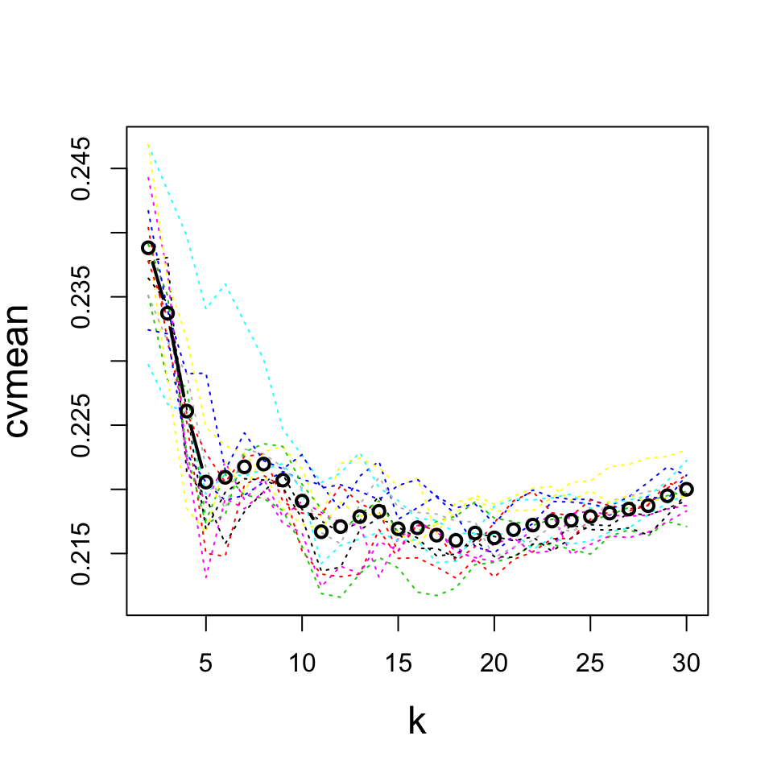

Plot of k verses cvmean, which compares the paramter k at values between 2 and 30 with the RMSE of each model (calculated by comparing against the testing data). Each colored line represents a different subset of the training data that, when averaged together to produce the black line, reduces bias and variance in the model.

```
## k= 2  rmse= 0.2337199
## k= 3  rmse= 0.2260977
## k= 4  rmse= 0.2205673
## k= 5  rmse= 0.2209378
## k= 6  rmse= 0.2217531
## k= 7  rmse= 0.221968
## k= 8  rmse= 0.2207189
## k= 9  rmse= 0.2190814
## k= 10  rmse= 0.2166978
## k= 11  rmse= 0.2170979
## k= 12  rmse= 0.217874
## k= 13  rmse= 0.2182884
## k= 14  rmse= 0.2169291
## k= 15  rmse= 0.2170059
## k= 16  rmse= 0.2164303
## k= 17  rmse= 0.216023
## k= 18  rmse= 0.2165946
## k= 19  rmse= 0.2162175
## k= 20  rmse= 0.2168612
## k= 21  rmse= 0.2172138
## k= 22  rmse= 0.2175274
## k= 23  rmse= 0.2175943
## k= 24  rmse= 0.2178783
## k= 25  rmse= 0.2181531
## k= 26  rmse= 0.2184624
## k= 27  rmse= 0.2187313
## k= 28  rmse= 0.2195027
## k= 29  rmse= 0.2200029
```

```
## optimal k= 17 with average rmse of  0.216023
```

Refit using k=17

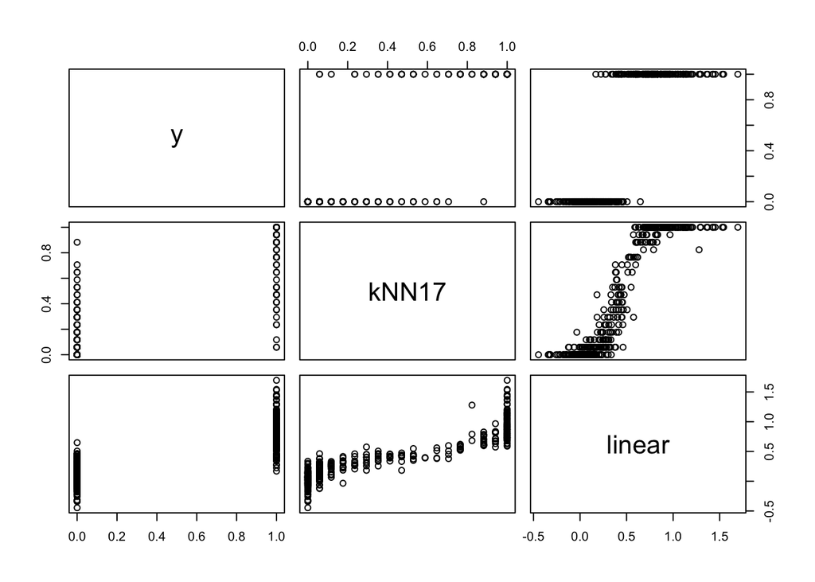

```
##                y     kNN17    linear
## y      1.0000000 0.9073875 0.8278193
## kNN17  0.9073875 1.0000000 0.9117653
## linear 0.8278193 0.9117653 1.0000000
```